# Homework 03

## Question 1: Build an `explain-to-me` skill

# explain-to-me

Use this skill when I explicitly ask you to use `explain-to-me` to read a homework question.

## Goal

Help me understand what the homework question is asking without solving the problem for me.

## Instructions

- Explain the main goal of the question in simple language.
- Break down what work I am expected to do.
- Clarify important statistical or mathematical terms if needed.
- Point me to the relevant Week 3 lecture topic, such as Ridge Regression: Stability Through Shrinkage or From a Penalized Objective to a Fitted Ridge Model.
- Give hints about how to start, but do not complete the solution, derivation, or final answer for me.
- Ask me what part is confusing if the question is ambiguous.

## Question 2: Ridge regression with nearly collinear predictors

1. The correlation between (X_1) and (X_2) is very close to 1, and the smallest singular value of (X) is much smaller than the largest one.

As () increases, the standard deviations of these coefficient estimates become much smaller.

The average test MSE is slightly lower for a small ridge penalty, but becomes larger when the penalty is too strong.

Ridge regression introduces some bias but reduces variance.

Because (X_1) and (X_2) are almost the same, many different combinations of (_1) and (_2) can produce similar fitted values. This makes the individual OLS coefficients unstable.

Ridge shrinks the coefficients and makes them much more stable, while the fitted values change much less because they depend mainly on the combined effect of (X_1) and (X_2).

## Question 3: What does ridge regression shrink?

The ridge objective is

[ L_() = |y-X|_2^2 + ||_2^2. ]

Taking the derivative with respect to (),

Therefore,

[ (X^TX+nI_p)_=X^Ty. ]

When (>0), (nI_p) makes the matrix (X^TX+nI_p) positive definite and invertible. Therefore, the ridge solution is unique even if (X) is rank deficient or (p>n).

Using

[ X=U_rD_rV_r^T, ]

the ridge fitted values can be written as

Here,

[ n(0.01)=1. ]

Therefore,

and

The third direction receives the strongest shrinkage because (d_3=0.2) is the smallest singular value.

A small singular value corresponds to a direction with little information in the design, so estimates in this direction can have high variance. Shrinking it can therefore reduce prediction variance.

However, if the true signal has a large component in this low-singular-value direction, strong shrinkage can remove an important part of the signal and produce substantial prediction bias.

## Question 4: Ridge regression and optimization

The eigenvalues of

[ A_0=X^TX ]

For ridge regression with (), the eigenvalues become

[ 9+0.09=9.09 ]

and

[ 0.01+0.09=0.10. ]

So ridge greatly improves the condition number. Geometrically, the objective becomes less elongated and more rounded, which makes optimization easier.

For gradient descent,

[ e^{(k+1)}=(I-A_)e^{(k)}. ]

So in an eigendirection with unpenalized eigenvalue (a), the error is multiplied by

[ 1-(a+). ]

To contract every direction,

[ |1-(a+)|<1, ]

Thus the large-eigenvalue direction converges much faster.

the contraction factor in the largest-eigenvalue direction is

[ 1-2.1=-1.1. ]

Since (|-1.1|>1), gradient descent does not converge.

A larger () improves the condition number and can make gradient descent converge faster.

However, () also changes the statistical model by shrinking the coefficients more strongly. If () is too large, this can introduce too much bias and hurt prediction accuracy.

Therefore, () should be chosen based on statistical performance, such as validation or test error, not only on optimization speed.

## Question 5: Selecting the ridge penalty for real-estate prediction

**Show the workflow**

```r
realestate <- read.csv("data/realestate.csv")
folds <- read.csv("data/realestate-split-folds.csv")
```

**Show the workflow**

```r
dat <- merge(realestate, folds, by = "row_id")

train <- dat[dat$split == "train", ]

xvars <- c("date", "age", "distance", "stores", "latitude", "longitude")
lambdas <- c(0, 10^seq(-4, 2, by = .05))

ridge_pred <- function(tr, va, lambda) {
  Xtr <- as.matrix(tr[, xvars])
  Xva <- as.matrix(va[, xvars])

  mu <- colMeans(Xtr)
  s <- apply(Xtr, 2, sd)

  Xtr <- scale(Xtr, center = mu, scale = s)
  Xva <- scale(Xva, center = mu, scale = s)

  ybar <- mean(tr$price)
  y <- tr$price - ybar

  b <- solve(t(Xtr) %*% Xtr + nrow(Xtr) * lambda * diag(6),
             t(Xtr) %*% y)

  ybar + Xva %*% b
}

cv <- sapply(lambdas, function(lam) {
  sapply(1:10, function(k) {
    tr <- train[train$cv_fold != k, ]
    va <- train[train$cv_fold == k, ]

    pred <- ridge_pred(tr, va, lam)
    mean((va$price - pred)^2)
  })
})

mse <- colMeans(cv)
se <- apply(cv, 2, sd) / sqrt(10)

i <- which.min(mse)
lambda_min <- lambdas[i]
lambda_1se <- max(lambdas[mse <= mse[i] + se[i]])

lambda_min
```

```
[1] 0.01995262
```

**Show the workflow**

```r
lambda_1se
```

```
[1] 1.584893
```

**Show the workflow**

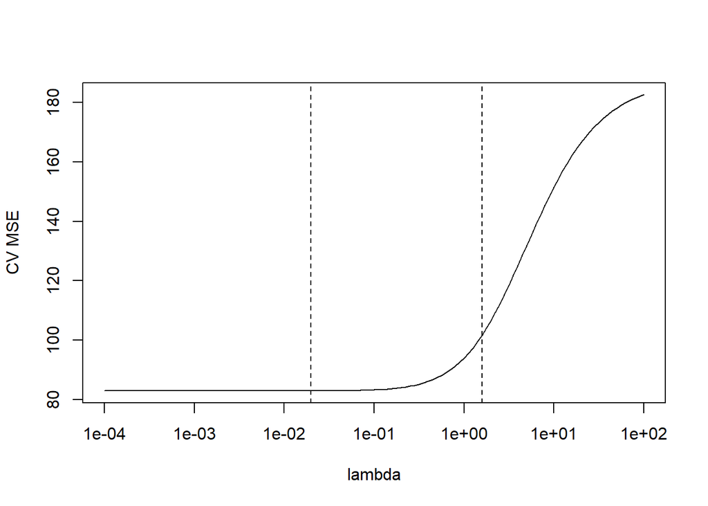

```r
plot(lambdas[-1], mse[-1], type = "l", log = "x",
     xlab = "lambda", ylab = "CV MSE")

abline(v = lambda_min, lty = 2)
abline(v = lambda_1se, lty = 2)
```

**Show the workflow**

```r
X <- as.matrix(train[, xvars])

mu <- colMeans(X)
s <- apply(X, 2, sd)
X <- scale(X, center = mu, scale = s)

ybar <- mean(train$price)
y <- train$price - ybar
n <- nrow(X)

gcv <- sapply(lambdas, function(lam) {
  A <- t(X) %*% X + n * lam * diag(6)
  b <- solve(A, t(X) %*% y)

  fit <- X %*% b
  rss <- sum((y - fit)^2)

  df <- 1 + sum(diag(X %*% solve(A, t(X))))

  (rss / n) / (1 - df / n)^2
})

lambda_GCV <- lambdas[which.min(gcv)]
lambda_GCV
```

```
[1] 0.02818383
```

**Show the workflow**

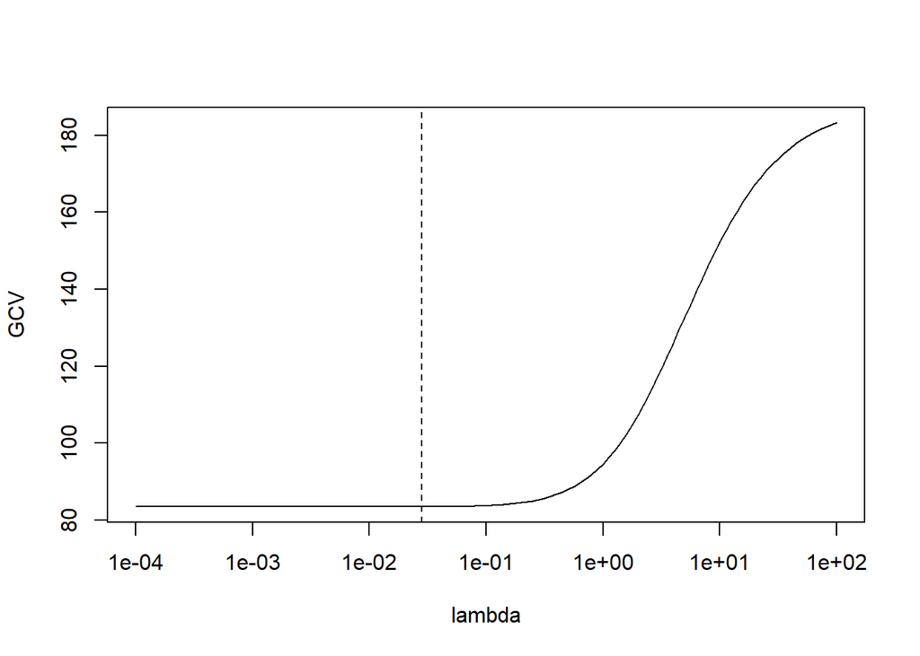

```r
plot(lambdas[-1], gcv[-1], type = "l", log = "x",
     xlab = "lambda", ylab = "GCV")

abline(v = lambda_GCV, lty = 2)
```

**Show the workflow**

```r
test <- dat[dat$split == "test", ]

final_fit <- function(lambda) {
  Xtr <- as.matrix(train[, xvars])
  Xte <- as.matrix(test[, xvars])

  mu <- colMeans(Xtr)
  s <- apply(Xtr, 2, sd)

  Xtr <- scale(Xtr, center = mu, scale = s)
  Xte <- scale(Xte, center = mu, scale = s)

  ybar <- mean(train$price)
  y <- train$price - ybar
  n <- nrow(Xtr)

  A <- t(Xtr) %*% Xtr + n * lambda * diag(6)
  b <- solve(A, t(Xtr) %*% y)

  pred_train <- ybar + Xtr %*% b
  pred_test <- ybar + Xte %*% b

  df <- 1 + sum(diag(Xtr %*% solve(A, t(Xtr))))

  c(
    train_mse = mean((train$price - pred_train)^2),
    test_mse = mean((test$price - pred_test)^2),
    df = df
  )
}

results <- rbind(
  OLS = final_fit(0),
  lambda_min = final_fit(lambda_min),
  lambda_1se = final_fit(lambda_1se),
  lambda_GCV = final_fit(lambda_GCV)
)

round(results, 3)
```

```
           train_mse test_mse    df
OLS           80.094   66.322 7.000
lambda_min    80.136   65.999 6.773
lambda_1se   100.435   81.260 3.029
lambda_GCV    80.172   65.902 6.688
```